# Alphabet Encodings and Formal languages

Prof. Dr. Raphael Volz

Hochschule Pforzheim

# Alphabets

## Character-encoding schemes

- Interpretation function maps bit sequences to characters
- Function is a typically a bijective mapping table
- Example schemes:
  - ASCII (American Standard Code for Information Interchange)
  - Unicode (ISO 10646)
  - Latin 1 (ISO 8859-1)
- ASCII Example
  - Uppercase letter **A**
  - Decimal number **65**
  - Binary **01000001**

## First 128 symbols in ASCII

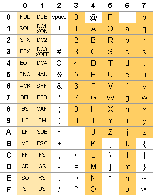

## Unicode Basic Multilingual Plane (BMP)

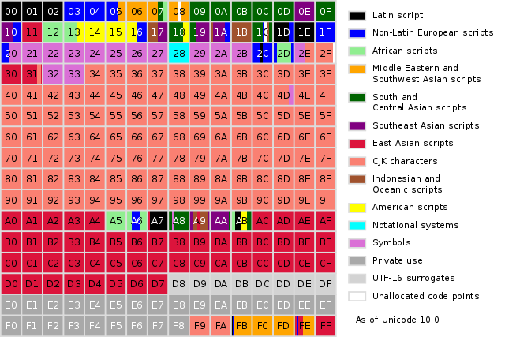

# Grammars

## Formal languages

Exploration on the board. Learning questions:

- What is a terminal ?
- What is a non-terminal ?
- What constitutes a grammar ?
- What is meant by production rule ?

## Avram Noam Chomsky

Father of modern linguistics (Professor emeritus MIT)

[figure not shown]

## Chomsky Hierarchy 101

| Type | Name | Additional restrictions |
| --- | --- | --- |
| 0 | Phrase structure grammar | No restrictions on form of production rules |
| 1 | Context-sensitive grammar | Left-hand side shorter than right-hand side for all production rules |
| 2 | Context-free grammar | Left-hand side of production rule is only a variable (non-terminal) |
| 3 | Regular grammar | Right-hand side of production rule is either a terminal or a terminal plus a variable |

## Computational complexity

**Membership problem:**

Given a set of data over $\Sigma$ does it belong to $L(G)$ ?

| Type | Membership problem decidable | Complexity |
| --- | --- | --- |
| 0 | No | Undecidable |
| 1 | Yes | exponential complexity (NP-hard) |
| 2 | Yes | $O(n^3)$ |
| 3 | Yes | $O(n)$ (linear complexity) |

## Recursion

- Production Rules can be recursive
- Recursion happens when variables appear (indirectly) on left and right-hand side of a production rule
- Often used in practice
- Example: Create a grammar for palindromes

[figure not shown]

## Movie: Grammar of happiness

[video not shown]

# EBNF

## John Backus (1924 - 2007)

[figure not shown]

**Turing Award (1977)**

*For profound, influential, and lasting contributions to the design of practical high-level programming systems, notably through his work on FORTRAN, and for seminal publication of formal procedures for the specification of programming languages.*

## Peter Naur (1928 - 2016)

[figure not shown]

**Turing Award (2005)**

*For fundamental contributions to programming language design and the definition of Algol 60, to compiler design, and to the art and practice of computer programming.*

## EBNF - Extended Backus-Naur Form

**Meta syntax** (Meta language) for definition of context free grammars

- Definitions are inline of production rules
  - Terminal symbols (Alphabet)
  - Non-Terminal symbols (Variables)
- Standard: ISO/IEC 14977:1996(E)
- Extended by Niklaus Wirth (ETH) to create a formal definition of the computer language Pascal

## EBNF Example

```
twelve = "1", "2";
non-zero-number = "1" | "2" | "3" | "4" | "5" | "6" | "7" | "8" | "9" ;
digit = "0" | non-zero-number ;
natural-number = non-zero-number, { Digit } ;
integer = "0" | [ "-" ], natural-number ;
```

## EBNF symbols

| Usage | Notation |
| --- | --- |
| definition | = |
| concatenation | , |
| termination | ; |
| alternation | \| |
| optional | [ … ] |
| repetition | { … } |
| grouping | ( … ) |
| terminal string | " … " or ‘…’ |

# Parsers

## Parser

A **parser** is a computer program that

- performs lexical and syntactic analysis
- analyses whether data conforms to a formal grammar
- creates an object representation of the data that can be used within programs
- provides meaningful error messages and reporting
- is mostly generated from a grammar via generators
- is always part of compilers and interpreters that translate computer programs into executable binary code

[Parser generator written in JavaScript](http://pegjs.org/online)

- Creates a parser program based on a grammar
- Metasyntax goes beyond EBNF
  - Embeds code fragments into production rules
  - Binds non-terminals in grammar to variables in code
  - Embedded code executed while processing data
- Generated parser is itself a JavaScript program
  - typically downloaded and embedded into own JavaScript programs (and Websites)
  - executed by the browser (or in other JS environments)

- Example: [Simple grammar for basic arithmetics](http://pegjs.org/online)
- Exercise: Change the grammar to allow division with remainder (modulo) using **%** notation

# Student Evaluation

## Please participate in the questionaire

[interactive chart not shown]